# What Is the State of the Job Market for Social Scientists and Data Analysts in the US in 2024?

Click on each tab below to discover different insights by topic.

### Top Skills

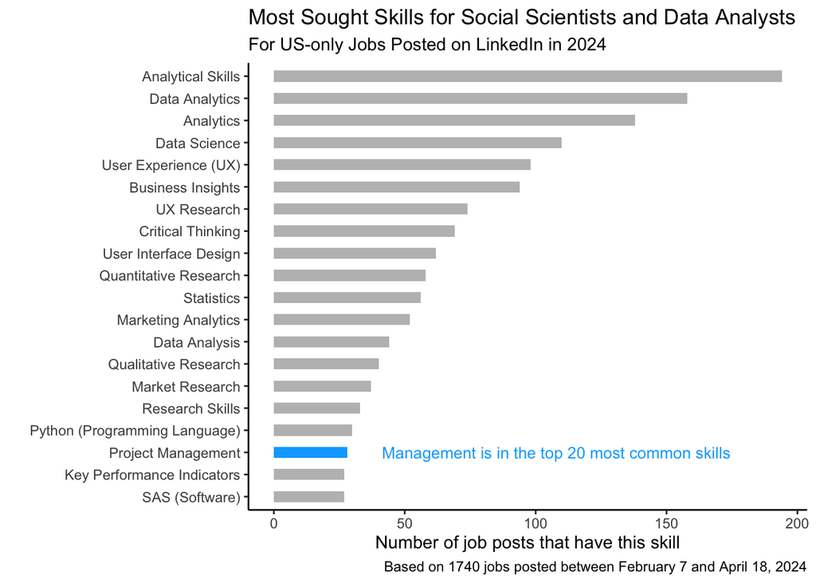

### Salaries

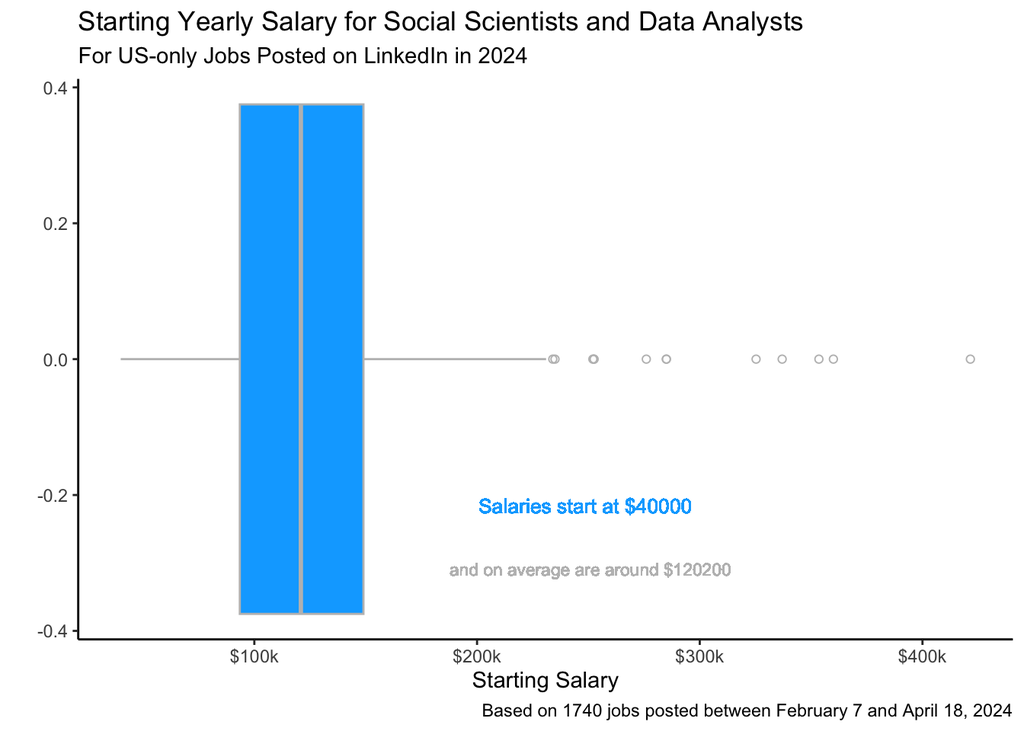

### Company Size

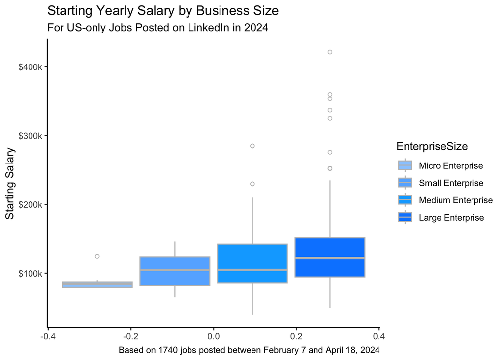

### Job Locations

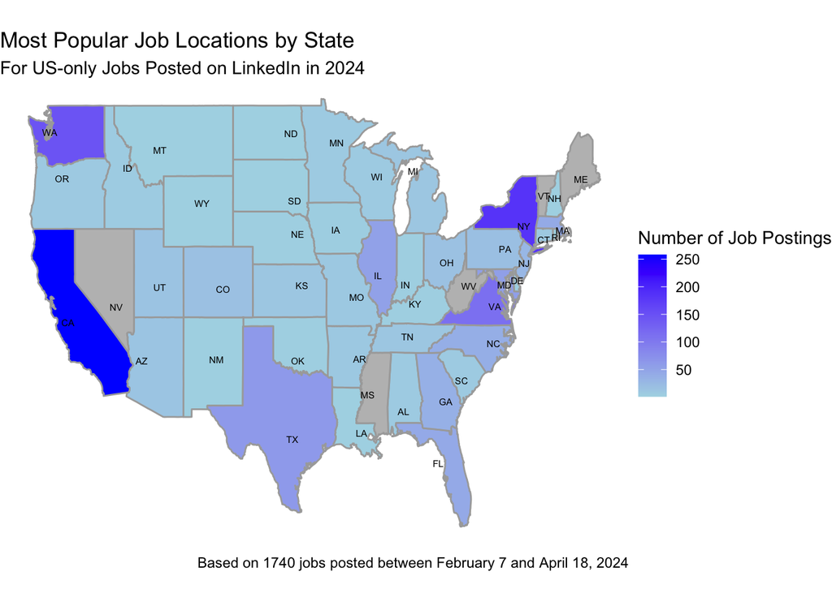

### Methodology

Job openings posted on LinkedIn are manually extracted by using a Google Chrome Extension ([Jobs Scraper & Exporter for LinkedIn](https://chromewebstore.google.com/detail/jobs-scraper-for-linkedin/jhmlphenakpfjkieogpinommlgjdjnhb)).

This extension allows users to download the first 20 jobs that appear on LinkedIn for any given search, along with multiple data points, such as the date published and the job poster.

All jobs searched are in the United States and a plethora of key words related to social science and data analytics are used to find akin jobs.

Below is the list of key words that were used to find jobs:

- Behavioral Economist
- Behavioral Scientist
- Data Analyst
- Data Scientist
- Human Factors
- Insights Analyst
- Marketing Analyst
- People Analytics
- Policy Analyst
- Product Analyst
- Social Scientist
- UX Researcher

Each key word was searched on a Thursday, filtering only for jobs that were posted in the past week.

Upon downloading all of the job posts, multiple data wrangling operations were performed to clean and enhance the dataset.

The data wrangling operations were performed using R, and include deduplicating job postings, searching for salary information in the job description, and locating mentions of key words such as “artificial intelligence”.

Below is a snipper of the resulting dataframe, which is also used to render all the plots and insights.

|  | Detail.URL | FileName | Title | Description | Description.HTML | Primary.Description | Location | Skill | Insight | Job.State | Poster.Id | Company.Name | Company.Logo | Created.At | NumEmployees | SalaryLowRange | SalaryHighRange | AverageSalary | AI_Count | AI_Binary | EnterpriseSize |
| --- | --- | --- | --- | --- | --- | --- | --- | --- | --- | --- | --- | --- | --- | --- | --- | --- | --- | --- | --- | --- | --- |
| 1 | https://www.linkedin.com/jobs/view/3856853423/ | Marketing Analyst | Senior Analyst - Marketing Analytics | BASIC PURPOSE: Responsible for supporting Global senior marketing leadership via producing strategic insights reports and strategic projects serving the company brands. Provide company decision makers… | &lt;p&gt;&lt;strong&gt;BASIC PURPOSE: &lt;/strong&gt;Responsible for supporting Global senior marketing leadership via producing strategic insights, reports, and strategic projects, serving the compan… | Norwegian Cruise Line Holdings Ltd. · Miami, FL (On-site) | Miami, Florida, United States | 3 of 4 skills match your profile - you may be a good fit | 10,001+ employees · Travel Arrangements 2 school alumni work here | LISTED | 812418260 | Norwegian Cruise Line Holdings Ltd. | https://media.licdn.com/dms/image/C560BAQEEcab13OPAtg/company-logo_400_400/0/1630663516608/norwegian_cruise_line_holdings_logo?e=1718841600&amp;v=beta&amp;t=F0K_krgjmqbeNRI3TCtqrLX8NGASR2GRsMz94UahlvA | 2024-03-15T16:53:48.000Z | 10,001+ |  |  |  | 0 | 0 | Large Enterprise |
| 2 | https://www.linkedin.com/jobs/view/3827996543/ | Behavioral Scientist; Human Factors; Social Scientist | Director, Data Science &amp; Machine Learning | Angi® is transforming the home services industry creating an environment for homeowners service professionals and employees to feel right at “home.” For most home maintenance needs our platform makes … | Angi® is transforming the home services industry, creating an environment for homeowners, service professionals and employees to feel right at “home.” For most home maintenance needs, our platform mak… | Angi | New York, New York, United States | 6 of 10 skills match your profile - you may be a good fit | 1,001-5,000 employees · Software Development 5 school alumni work here | LISTED | 247444258 | Angi | https://media.licdn.com/dms/image/C4D0BAQEgk8MjLI5aEg/company-logo_400_400/0/1630461500802/angi_logo?e=1716422400&amp;v=beta&amp;t=4DC1tVAIz-iMoMkTQjRgMlxBAr4sG_XKHseDsQwE4ag | 2024-02-15T21:05:59.000Z | 1,001-5,000 | 220000 | 300000 | 260000 | 0 | 0 | Large Enterprise |